# Oak-Hickory

This page summarizes regeneration of oak and hickory in plots classified as oak-hickory communities. Regeneration is evaluated from counts of seedlings and saplings (and, for some metrics, small trees) of oak and hickory species, compared with those of all other species.

### SIDEBAR

**Choose a SubPark**

Select the SubPark to display. This selection applies to the three plot-level tabs: Oak Sustainability Index, log(Importance), and Relationship between OSI & log(Importance). The Sander threshold tabs show all SubParks together, so they do not change with this selection.

### GRAPHS AND TABLES

Each of the first three tabs shows one value for every oak-hickory plot in the selected SubPark. The points are the mean of bootstrapped estimates for that plot and the vertical lines are 95% bootstrapped confidence intervals. Colors show the survey cycle. A dashed vertical line means the plot had a prescribed burn before that survey (for a plot’s first survey, any recorded prior burn; for later surveys, a burn since the plot’s previous survey, or within the past five years if the plot has no earlier survey). QAQC surveys are not included.

#### Oak Sustainability Index (OSI)

The OSI describes how much of the regeneration in a plot is oak and hickory. It is calculated separately for seedlings and for saplings, and the two values are added. For each group, the ratio is the oak-hickory score divided by the score for all species combined:

$$\text{OSI} = \frac{\text{OH}_{seedling}}{\text{OH}_{seedling} + \text{notOH}_{seedling}} + \frac{\text{OH}_{sapling}}{\text{OH}_{sapling} + \text{notOH}_{sapling}}$$

- Seedling score = (count of seedlings 5 cm to <137 cm tall × 50) + (count of saplings 0 to <2.5 cm DBH × 5), with counts scaled up to the 400 m<sup>2</sup> plot.
- Sapling score = (count of saplings 2.5 to <10 cm DBH × 5, scaled up to the 400 m<sup>2</sup> plot) + (count of live trees 10 to 15 cm DBH).
- If a plot has no seedlings (or no saplings) of any species, that ratio is set to 0.

Each ratio ranges from 0 to 1, so the OSI ranges from 0 to 2. Higher values mean oak and hickory make up a larger share of the regeneration. The red horizontal lines are at 0.5 (dashed) and 1.0 (solid).

Because the OSI is a ratio, it describes the *composition* of regeneration (how much is oak-hickory), not how much regeneration there is. A plot with very few seedlings and saplings can have a high OSI. Use the OSI together with log(Importance).

#### log(Importance)

The Importance score describes the *amount* of oak-hickory regeneration in a plot. Each oak-hickory stem is given points according to its size, so that larger stems count for more, and the points are summed and scaled up to a per-hectare value:

- Seedlings 5 to <30 cm tall = 1 point each
- Seedlings 30 to <50 cm tall = 2 points each
- Seedlings 50 to <137 cm tall = 10 points each
- Saplings (all size classes, up to 10 cm DBH) = 50 points each
- Live oak-hickory trees = 50 points each

The graph shows the natural log of the total score (plus 1, so that plots with no oak-hickory stems can be shown). Higher values mean more, and larger, oak-hickory regeneration. The red horizontal lines are at 5 (dashed) and 10 (solid).

#### Relationship between OSI & log(Importance)

This scatterplot shows each plot in the selected SubPark as a point, with the plot’s OSI on the x axis and its log(Importance) on the y axis. It helps show whether plots with a high share of oak-hickory regeneration (OSI) also have a large amount of it (log(Importance)). Plots in the upper right have both; plots with a high OSI but low log(Importance) have regeneration that is mostly oak-hickory but sparse.

#### Sander threshold

**Graph (Sander threshold tab) and table (Sander threshold table tab)**

The Sander metric considers only saplings in the DBH classes 0-1 cm, 1-2.5 cm, and 2.5-5 cm. Saplings are counted in eight 10-m<sup>2</sup> boxes in each surveyed plot. If the number of oak-hickory saplings exceeds about 1000 per hectare, the plot is considered to have adequate advanced regeneration of oak-hickory (Sander et al. 1976). This threshold is equivalent to 1 oak-hickory sapling per 10-m<sup>2</sup> box, so the densities on this page are shown as the number of oak-hickory saplings per 10-m<sup>2</sup> box. A value greater than 1 means the Sander threshold is surpassed.

The estimates come from hierarchical bootstrapping of the survey data: plots are resampled, and then the eight box counts are resampled within each selected plot. Each point is the median of the bootstrapped mean densities for a SubPark and each vertical line is the 90% confidence interval (5% to 95% quantiles). The dashed blue line is the Sander threshold (1 sapling per 10-m<sup>2</sup> box). The graph is shown separately for oak-hickory communities and for ruderal communities, and the table gives the same values along with ‘Nplots’, the number of plots surveyed in that SubPark. Only the first survey cycle is used.

In the example below, the SubPark with the highest estimate is SHIL. Ninety percent of the bootstrapped mean densities for SHIL oak-hickory communities were between about 0.34 and 0.68 oak-hickory saplings per 10-m<sup>2</sup> box, and half were below about 0.51. Even when sampling variability is taken into account, none of the oak-hickory communities shown has an average density that reaches the threshold of 1.

Bootstrapped confidence intervals (like any other method of estimation) are not recommended for very small sample sizes, but there are no clear rules of thumb for a minimum. Be wary of estimates for SubParks with few surveyed plots.

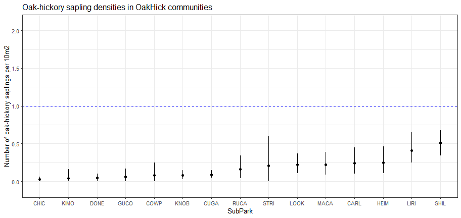